# GIS-based multi-criteria analysis for mapping flood-prone areas in Assam

CDL - JeenoGeorge

March, 2022

## 1. Introduction

In order to measure the proneness of an area to flooding, it is necessary to identify the flood controlling factors.In the present study, we selected eight flood causative factors based on comprehensive literature review presented by (Allafta, H., & Opp, C. (2021)) (https://www.tandfonline.com/doi/full/10.1080/19475705.2021.1955755). The eight flood controlling parameters are rainfall, distance to the river, elevation, slope, LULC, drainage density, soils and lithology. The reason for selecting the controlling factors are listed in the table below.

[output not shown]

```r
assam_bound <- terra::rast("assam_stdy_area.tif")
```

## 3. Data

The section details about the data used to map the flood-prone areas of Assam.

We are going to load the following libraries:

```r
packages <- c("terra", "raster", "sp", "sf", "tidyr", "rgdal", "dplyr", "tidyverse","ncdf4","ggplot2")
```

First, we read the study area.

```r
assam_bound <- terra::rast("assam_stdy_area.tif")
```

### Data Sources

```r
#read the netCDF file
nc_data <- nc_open('2021.nc')
nf <- terra::rast('2021.nc')

#sum daily rainfall to get annual rainfall
nf_sum <- sum(nf)

#write the raster
writeRaster(nf_sum,'rainfall_2021.tif', overwrite = T )
```

Read the rainfall data we have already prepared for the years from 2015 to 2021.

```r
R_15 <- rast('rainfall_2015.tif')
R_16 <- rast('rainfall_2016.tif')
R_17 <- rast('rainfall_2017.tif')
R_18 <- rast('rainfall_2018.tif')
R_19 <- rast('rainfall_2019.tif')
R_20 <- rast('rainfall_2020.tif')
R_21 <- rast('rainfall_2021.tif')
```

Next, we calculating the mean annual rainfall. Here we have plotted the data for visualisation.

```r
rainfall <- c(R_15, R_16, R_17, R_18, R_19, R_20, R_21)
R_mean <- mean(R_15, R_16, R_17, R_18, R_19, R_20, R_21)
R_mean
```

```
## class       : SpatRaster
## dimensions  : 129, 135, 1  (nrow, ncol, nlyr)
## resolution  : 0.25, 0.25  (x, y)
## extent      : 66.375, 100.125, 6.375, 38.625  (xmin, xmax, ymin, ymax)
## coord. ref. : lon/lat WGS 84 (EPSG:4326)
## source      : memory
## name        :      sum
## min value   : 88.25242
## max value   : 10288.39
```

##plotting the mean annual rainfall

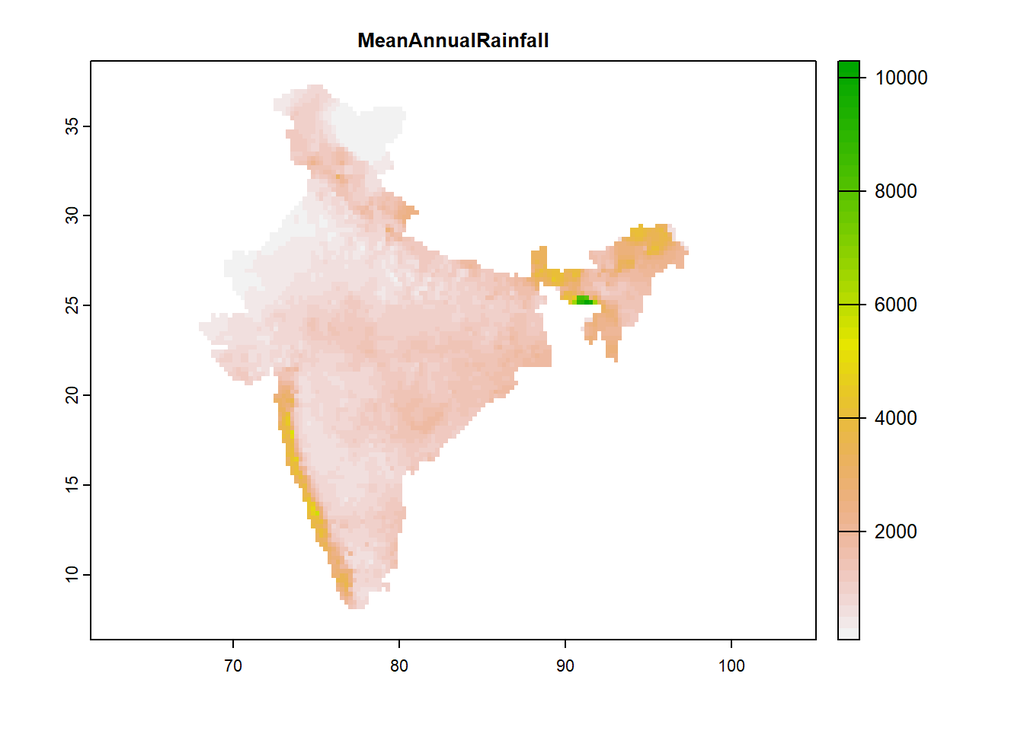

Next, we can transform the rainfall data to a new data set with another CRS using the project method and crop it to the study area boundary.

```r
R_mean <- terra::project(R_mean , assam_bound, overwrite = T)
R_mean <- terra::crop(R_mean , assam_bound, overwrite = T)
R_mean <- terra::mask(R_mean , assam_bound, overwrite = T)
```

The line shapefile of major rivers of India is available at [ArcGIS Feature Service](https://arc.indiawris.gov.in/server/rest/services/SubInfoSysLCC) from India-WRIS.The major rivers are buffered by 2km,5km,10km,15km,20km,25km,50km and 100km. The polygon shapefiles are merged and converted to a raster file in qGIS.

```r
riv_dist <- rast("assam_dist_from_major_rivers.tif")
```

Next, we can transform the distance from the river data to a new data set with another CRS using the project method and crop it to the study area boundary.

```r
riv_dist <- terra::project(riv_dist , assam_bound, overwrite = T)
riv_dist <- terra::crop(riv_dist , assam_bound, overwrite = T)
riv_dist <- terra::mask(riv_dist , assam_bound, overwrite = T)
```

DEM data were aquired from [EarthExplorer](https://earthexplorer.usgs.gov/) by searching for Assam and choosing STRM 1 Arc-Second Global in Digital Elevation Satellite images. The ‘fill sinks’ function in qGIS is used to fill the DEM. The filled DEM is used here.

```r
srtm_dem <- rast("srtm_filled_dem.tif")
```

Next, we can transform the filled DEM data to a new data set with another CRS using the project method and crop it to the study area boundary.

```r
srtm_dem_prj <- terra::project(srtm_dem, assam_bound, overwrite = T)
srtm_dem_prj <- crop(srtm_dem_prj , assam_bound)
srtm_dem_prj <- mask(srtm_dem_prj , assam_bound, overwrite = T)
```

From the filled DEM, the ‘slope’ function in raster analysis of qGIS can give the slope map.

```r
srtm_slope <- rast("strm_filled_slope_degrees.tif")
```

Next, we can transform the slope map to a new data set with another CRS using the project method and crop it to the study area boundary.

```r
srtm_slope_prj <- terra::project(srtm_slope, assam_bound, overwrite = T)
srtm_slope_prj <- crop(srtm_slope_prj , assam_bound)
srtm_slope_prj <- mask(srtm_slope_prj , assam_bound, overwrite = T)
```

The landuse map of Assam was not available for use in this analysis and supervised or unsupervised classification of land cover satellite images was not attempted due to the availability of [global gridded curve numbers for hydrologic modeling and design](https://www.ncbi.nlm.nih.gov/pmc/articles/PMC6690949/) . The runoff curve number (abbreviated CN) is an empirical parameter used in hydrology to estimate direct runoff or infiltration due to excess rainfall. The resulting data product – GCN250 – represents runoff using a combination of the European space agency’s 2015 global land cover dataset (ESA CCI-LC) resampled to 250 metres and geo-registered with the hydrologic soil group’s global data product (HYSOGs250m) released in 2018. The average GCN is taken for the analysis and cropped to Assam study boundary.

```r
gcn_global <- terra::rast("GCN250_ARCIII_average.tif")
assam <- terra::vect("assam_state_buffer.shp")
gcn_assam <- terra::crop(gcn_global, assam)
```

Next, we can transform the average GCN map to a new data set with another CRS using the project method and crop it to the study area boundary.

```r
gcn_assam <- terra::project(gcn_assam , assam_bound, overwrite = T)
gcn_assam <- terra::crop(gcn_assam , assam_bound, overwrite = T)
gcn_assam <- terra::mask(gcn_assam , assam_bound, overwrite = T)
```

The drainage density indicates the closeness of spacing between channels and is a measure of the total length of the stream segment of all orders per unit area. In general it has been observed over a wide range of geologic and climatic types, that low drainage density is more likely to occur in regions of highly permeable subsoil material under dense vegetative cover, and where relief is low. In contrast, high drainage density is favored in regions of weak or impermeable subsurface materials, sparse vegetation and mountainous relief (Nag, 1998).

The stream channels derived from the DEM is available as line shape file at India-WRIS for orders three and above. The shape file has to be re-projected to WGS 84 / Pseudo-Mercator (EPSG:3857). In qGIS, the function line density is used to get the drainage density using the stream channels of order three and above, entering the search radius as 10 km and pixel size as 1 km.

```r
drn_den <- terra::rast("drainage_density.tif")
```

Next, we can transform the drainage density map to a new data set with another CRS using the project method and crop it to the study area boundary.

```r
drn_den_prj <- terra::project(drn_den, assam_bound, overwrite = T)
drn_den_prj <- terra::crop(drn_den_prj , assam_bound)
drn_den_prj <- terra::mask(drn_den_prj , assam_bound, overwrite = T)
```

```r
as_lith <- terra::rast("assam_lith.tif")
```

Next, we can transform the lithology map to a new data set with another CRS using the project method and crop it to the study area boundary.

```r
as_lith <- terra::project(as_lith , assam_bound, overwrite = T)
as_lith <- terra::crop(as_lith , assam_bound, overwrite = T)
as_lith <- terra::mask(as_lith , assam_bound, overwrite = T)
```

The soil map of the study area is categories into four major classes : clayey, loamy, rocky and sandy.

```r
as_soil <- terra::rast("assam_soil.tif")
```

Next, we can transform the soil map to a new data set with another CRS using the project method and crop it to the study area boundary.

```r
as_soil <- terra::project(as_soil , assam_bound, overwrite = T)
as_soil <- terra::crop(as_soil , assam_bound, overwrite = T)
as_soil <- terra::mask(as_soil , assam_bound, overwrite = T)
```

##Identification of flood hazard zones During the analysis, weight scores were allocated to the thematic layers and their classes according to their significance in flood vulnerability. Total scores were computed using a simple weighted sum. Each pixel of the output map was calculated using the following equation:
$$H_i = \sum_{j}{w_j * X_{ij}}$$
where, Xij denotes the rank score of each class with respect to the j layer, and Wj represents the normalized weight of the j layer.

##Classifying the thematic layers and assigning values to the classes

Rainfall (mm/year) : Rainfall is a major triggering factor for flood generation (Subbarayan and Sivaranjani 2020) since it directly relates to river discharge (Das 2018). The ‘cut’ function divides the range of values pf the layer into specified number of intervals and codes the values according to which interval they fall. The leftmost interval corresponds to level one, the next leftmost to level two and so on. Thus, the rightmost interval that corresponds to level five also indicates the highest rainfall (mm/year).

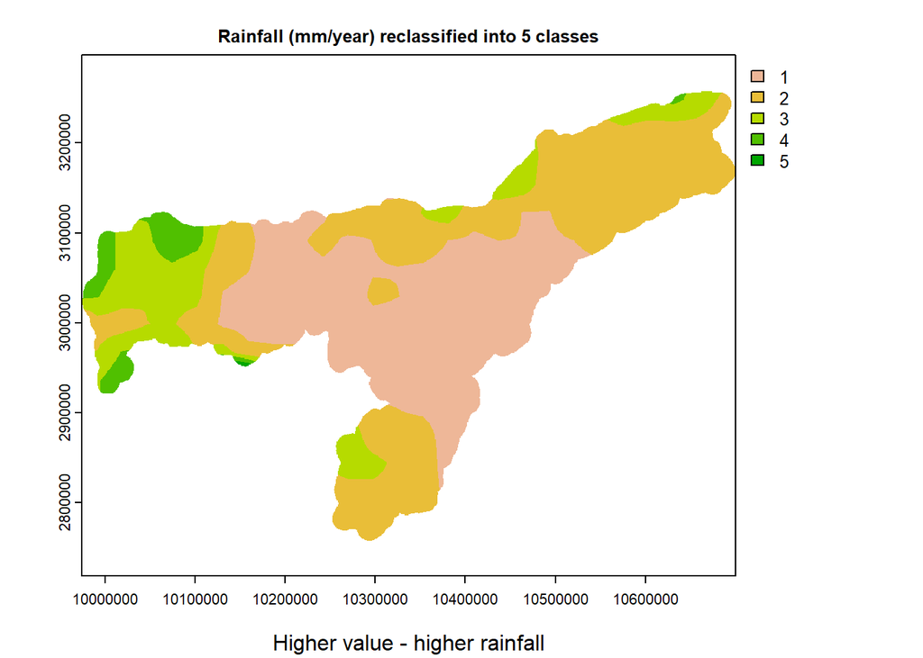

```r
#reclassify - RAINFALL
#range(R_mean[], na.rm=T)
rain_levels <- cut(R_mean[], breaks = 5,include.lowest =T, na.rm = T)
tt <- cut(R_mean[],labels = c(1,2,3,4,5), include.lowest =T,breaks = 5, na.rm = T)
rain <- R_mean
values(rain) <- tt
rain <- rain+1 # to avoid the value '0'
plot(rain, main = "Rainfall (mm/year) reclassified into 5 classes")
mtext("Higher value - higher rainfall",  side = 1, line = 2)
```

Distance to the river (km): When flooding occurs, the closer the area to the river course are the more vulnerable areas to flooding.

```r
#reclassify - river distance
rivdist_levels <- cut(riv_dist[], breaks = 5,include.lowest =T, na.rm = T)
levels(rivdist_levels)
```

```
## [1] "[1.9,21.6]"  "(21.6,41.2]" "(41.2,60.8]" "(60.8,80.4]" "(80.4,100]"
```

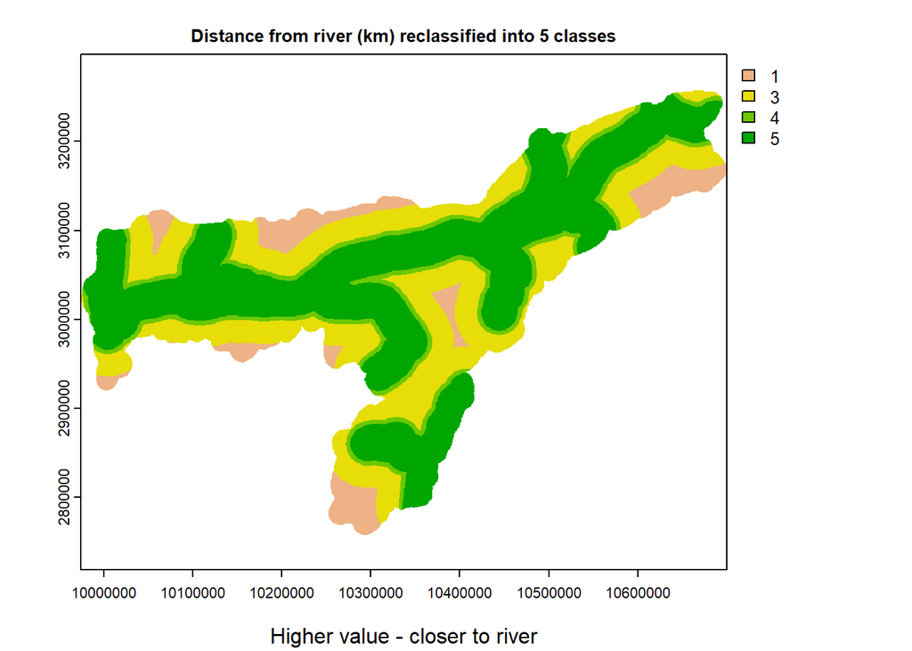

```r
tt <- cut(riv_dist[],labels = c(5,4,3,2,1), breaks = 5,include.lowest =T, na.rm = T)
rivdist <- riv_dist
values(rivdist) <- tt
rivdist <- 6-(rivdist + 1) #to invert the values
plot(rivdist, main = "Distance from river (km) reclassified into 5 classes")
mtext("Higher value - closer to river", side = 1, line = 2)
```

Elevation : Runoff flows from high to low terrains, therefore the flood incidence likelihood in low-elevated regions is higher.

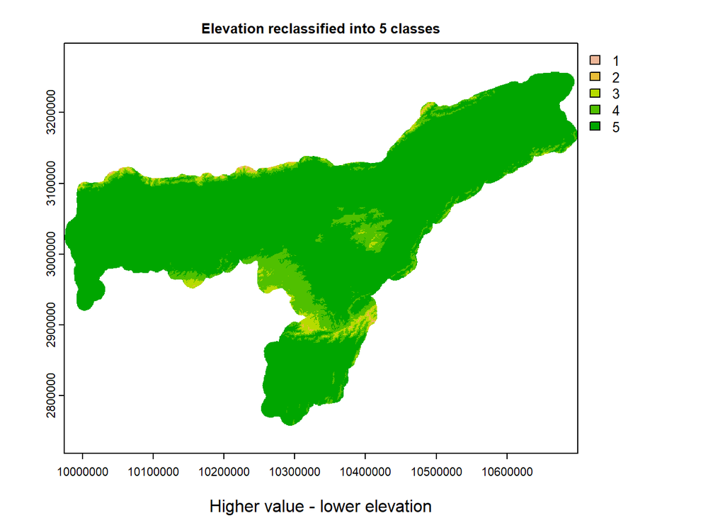

```r
elev_levels <- cut(srtm_dem_prj[], breaks = 5,include.lowest =T, na.rm = T)
tt <- cut(srtm_dem_prj[],labels = c(5,4,3,2,1), breaks = 5, include.lowest =T,na.rm = T)
ele <- srtm_dem_prj
values(ele) <- tt
ele <- 6-(ele+1)
plot(ele, main = "Elevation reclassified into 5 classes")
mtext("Higher value - lower elevation", side = 1, line = 2)
```

Slope (degrees) : The surface slope influences the velocities of overland flow and the concentration of flow. The probability of a flood increases as the slope of a region decreases, making it a solid indicator for flood vulnerability evaluation. A high slope supports quick water drainage, whereas low slope results in stagnation of water, and promoting flooding.

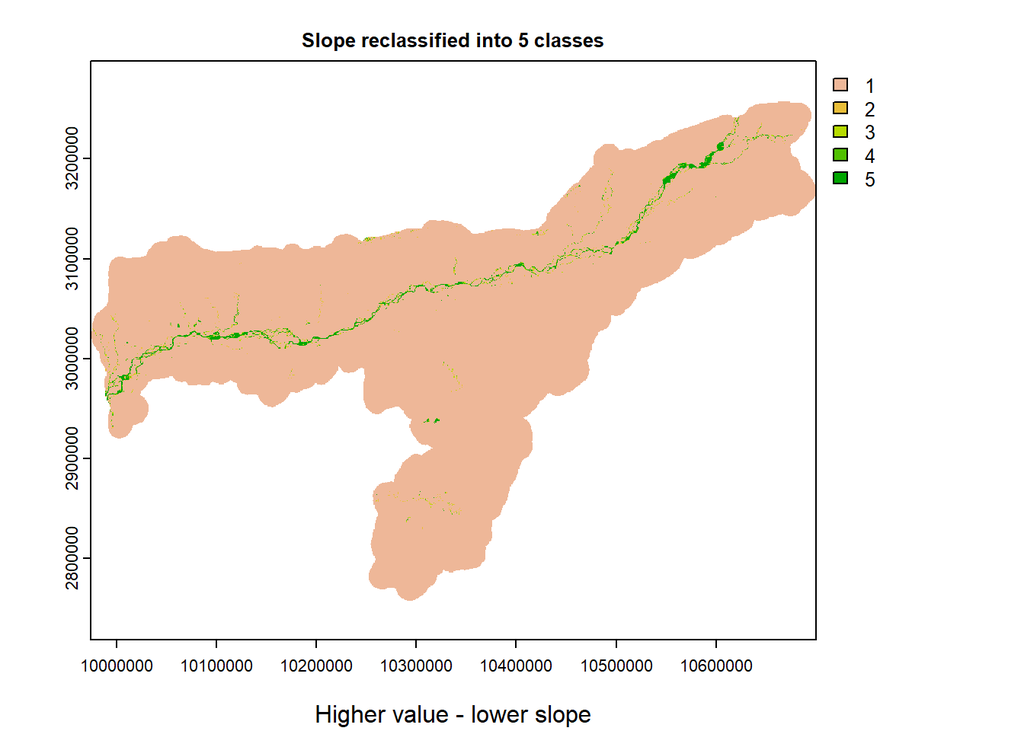

```r
slope_levels <- cut(srtm_slope_prj[], breaks = 5,include.lowest =T, na.rm = T)
tt <- cut(srtm_slope_prj[],labels = c(5,4,3,2,1), breaks = 5,include.lowest =T, na.rm = T)
sloper <- srtm_slope_prj
values(sloper) <- tt
sloper <- 6-(sloper+1)
plot(sloper, main = "Slope reclassified into 5 classes")
mtext("Higher value - lower slope", side = 1, line = 2)
```

Curve number :

```r
gcn_levels <- cut(gcn_assam[], breaks = 5,include.lowest =T, na.rm = T)
levels(gcn_levels)
```

```
## [1] "[75,79.6]"   "(79.6,84.2]" "(84.2,88.8]" "(88.8,93.4]" "(93.4,98]"
```

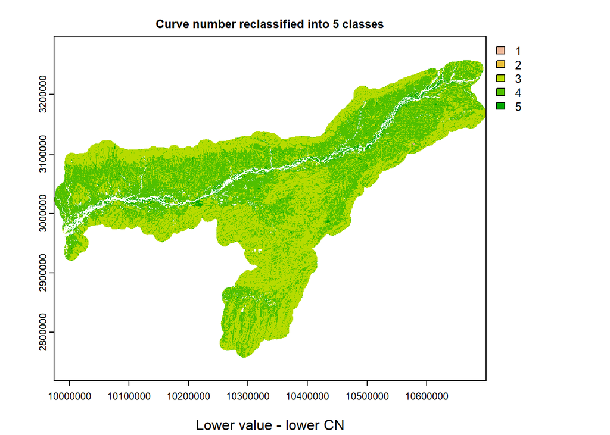

```r
tt <- cut(gcn_assam [],labels = c(5,4,3,2,1), breaks = 5,include.lowest =T, na.rm = T)
gcn <- gcn_assam
values(gcn) <- tt
gcn <- (gcn+1)
plot(gcn, main = "Curve number reclassified into 5 classes")
mtext("Lower value - lower CN", side = 1, line = 2)
```

Drainage density : Flood hazard is proportionally related to drainage density because higher drainage promotes a higher surface water flow and virtually increases the flooding susceptibility.

```r
drnden_levels <- cut(drn_den_prj[], breaks = 5,include.lowest =T, na.rm = T)
levels(drnden_levels)
```

```
## [1] "[2.64e-05,0.000188]" "(0.000188,0.000348]" "(0.000348,0.000508]"
## [4] "(0.000508,0.000669]" "(0.000669,0.00083]"
```

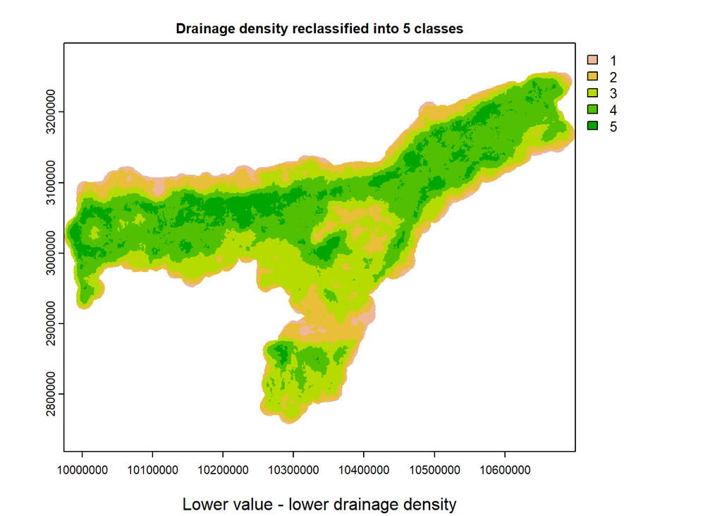

```r
tt <- cut(drn_den_prj [],labels = c(1,2,3,4,5), breaks = 5, include.lowest =T,na.rm = T)
drn_den <- drn_den_prj
values(drn_den) <- tt
drn_den <- drn_den+1
plot(drn_den,  main = "Drainage density reclassified into 5 classes")
mtext("Lower value - lower drainage density", side = 1, line = 2)
```

```r
y <- classify(as_soil, cbind(id=c(56,230,254,255), v=c(5,3,0,1.5)))
unique(y[])
```

```
##      assam_soil
## [1,]        NaN
## [2,]        1.5
## [3,]        0.0
## [4,]        5.0
## [5,]        3.0
```

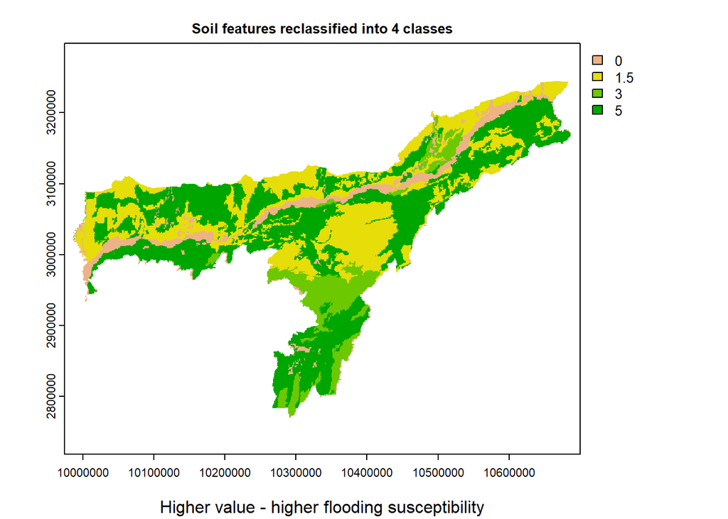

```r
soil <- y
plot(soil,  main = "Soil features reclassified into 4 classes")
mtext("Higher value - higher flooding susceptibility", side = 1, line = 2)
```

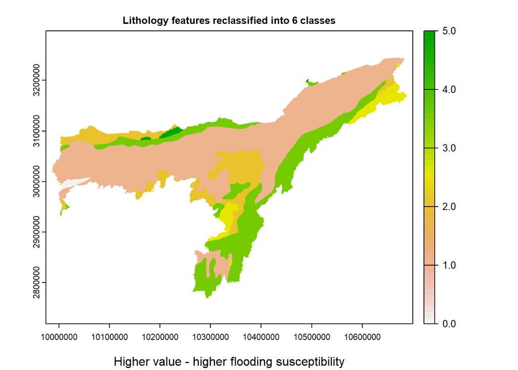

```r
y_lith <- classify(as_lith, cbind(id=c(1,2,3,4,5,6,7,8), v=c(0,5,3.5,2,3.5,2,1,2.5)))
lith <- y_lith
plot(lith, main = "Lithology features reclassified into 6 classes")
mtext("Higher value - higher flooding susceptibility", side = 1, line = 2)
```

##Flood hazard zoning The selected eight factors produces a flood hazard map. The highest weightage of 0.20 was given to ‘distance from the river’ as the most common type of flood in the region are fluvial floods due to the dense network of rivers.

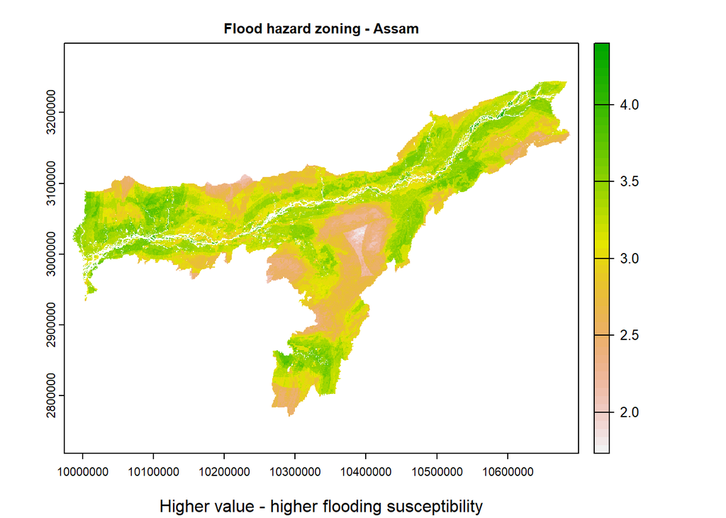

```r
#flood exposure mapper
floo_vul <- .15*rain + (.20)*rivdist + .10*drn_den + (.15)*sloper +
  (.15)*ele + (.08)*soil + (.05)*lith + (.12)*gcn
plot(floo_vul, main = "Flood hazard zoning - Assam")
mtext("Higher value - higher flooding susceptibility", side = 1, line = 2)
```

The district-wise mean values of flood hazard can be extracted from the flood hazard zoning map.

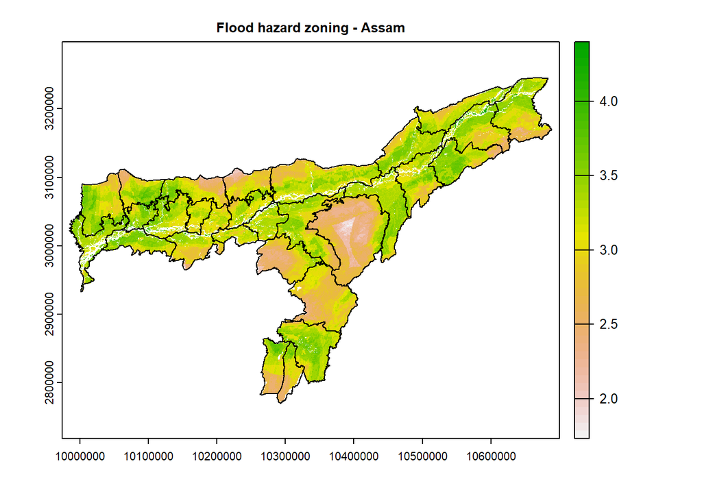

```r
district_27 <- terra::vect("assam_district_27.shp")
plot(floo_vul, main = "Flood hazard zoning - Assam")
plot(district_27, add=T)
```

```r
floo_vul_d <- terra::extract(floo_vul, district_27, fun = mean, na.rm= T, df = T)
district_27$floo_vul <- floo_vul_d$sum
as.data.frame(district_27) %>% arrange(desc(floo_vul)) %>% dplyr::select(dtname, floo_vul)
```

```
##                 dtname floo_vul
## 1           Bongaigaon 3.415277
## 2               Dhubri 3.388288
## 3             Goalpara 3.366326
## 4               Cachar 3.323932
## 5             Golaghat 3.320242
## 6            Sivasagar 3.306790
## 7              Barpeta 3.302372
## 8            Lakhimpur 3.293335
## 9             Morigaon 3.282884
## 10           Kokrajhar 3.250396
## 11             Chirang 3.240043
## 12             Darrang 3.210357
## 13           Dibrugarh 3.195389
## 14              Jorhat 3.194960
## 15             Dhemaji 3.189704
## 16 Kamrup Metropolitan 3.182493
## 17              Nagaon 3.179163
## 18            Sonitpur 3.143476
## 19             Nalbari 3.142826
## 20            Tinsukia 3.126327
## 21              Kamrup 3.047577
## 22           Karimganj 3.039930
## 23               Baksa 3.021004
## 24          Hailakandi 2.984741
## 25            Udalguri 2.863783
## 26          Dima Hasao 2.857159
## 27       Karbi Anglong 2.651055
```

##Conclusion In the following work, the generated ‘flood hazard zoning’ map can be compared with actual flood maps of Assam to validate the work.